# Homework 2

## Problem 1 (2pts each, 8pts total)

Here are a few probability exercises to get you warmed up.

1. Consider $X\sim \text{Normal}(5, 2^2)$. Find $P(4 < X < 7)$

```r
pnorm(7, 5, 2) - pnorm(4, 5, 2)
```

```
## [1] 0.5328072
```

2. Suppose you have an uneven 6-sided die where the even numbers are equally likely to occur and the odd numbers are also equally likely. The expected value of the die is $3.3333$ (i.e. $\frac{10}{3})$. What is the probability of getting a 6? (Hint: Let $p$ represent the probability of getting an even number, and represent the probability of the other numbers algebraically. Then derive an expression for the expected value, let it equal $\frac{10}{3}$, and solve. You can go back and check your work by plugging the result back into your original expressions and verify it works with R.)

   $$2p + 4p + 6p + o + 3o + 5o =
   \frac{10}{3} = 12p + 9o$$
   $$36p + 27o
   = 10$$
   Notice we can represent $o$ with the expression $\frac{1 - 3p}{3}$, now substitute:
   $$36p + 9(1 - 3p) = 10$$
   Simplify:
   $$9p = 1$$
   There will be a $\frac{1}{9}$ chance of any even number, including 6.
3. Give **two examples** of pairs of events that are mutually exclusive and explain why for each.

Consider the trial of flipping a 2 sided coin a single time. Mutually exclusive events are: trial results in heads, the same trial results in tails. A coinflip is binary, it must land on one side so the probability of both happening at the same time is 0.

Rolling a 1 on a fair 6 sided dice, rolling a 2 on a fair 6 sided dice. A dice roll comes from a uniform discrete distribution, you can get only one outcome for a single dice roll.

4. Give **two examples** of pairs of events that are independent and explain why for each.

Flipping a coin and getting heads $E_1$, flipping another coin and getting heads $E_2$. The outcomes are $\{\{H, T\}. \{T, H\}, \{H, H\}, \{T, T\}\}$. $P[E_1 \cap E_2] = \frac{1}{4}$, $P[E_1] = \frac{1}{2}$, $P[E_2] = \frac{1}{2}$, $P[E_1] \cdot P[E_2] = \frac{1}{4}$. We have $P[E_1 \cap E_2] = P[E_1]P[E_2]$.

Rolling a fair 6 sided die and getting an even number $E_1$, rolling another fair 6 sided die and getting an odd number $E_2$. The outcomes are $\{\{E, E\}. \{E, O\}, \{O, O\}, \{O, E\}\}$. $P[E_1 \cap E_2] = \frac{1}{4}$. $P[E_1] = \frac{1}{2}$, $P[E_2] = \frac{1}{2}$, $P[E_1] \cdot P[E_2] = \frac{1}{4}$. We have $P[E_1 \cap E_2] = P[E_1]P[E_2]$.

## Problem 2 (2pts each, 14pts total)

For each of the following scenarios, decide what random variable may be appropriate to use as a model, and explain your reasoning as well as any assumptions you make.

1. The number of patients in an experimental drug trial that respond to treatment.

Binomial. Some percentage of patients will respond, and it is binary.

2. The number of red cars you observe driving through an intersection between 10am and 11am.

Poisson. There should be an average amount of cars that could represent $\lambda$.

3. What the second hand reads on the clock when you wake up from a long nap (approximately).

Discrete uniform. Time is distributed uniformly and you have a the same chance to wake up at each second.

4. How many people you need to swipe right on Tinder before you get a match.

Geometric. This is the number of times you need to perform a Binomial trial before a match.

5. The length of time between mosquito bites a camper experiences while on a hike.

Exponential. This is to model the time between events.

6. Whether the Eagles win the Superbowl this year.

Bernoulli. Each year is a trial, and the Eagles have a given chance to win each year, but we are talking about only this year.

7. The GPA of a randomly selected UW-Madison graduate.

Normal. There should be a mean GPA and some amount of variability.

## Problem 3 (2pts each, 4pts total)

1. Consider the CDF given below for random variable $Y$

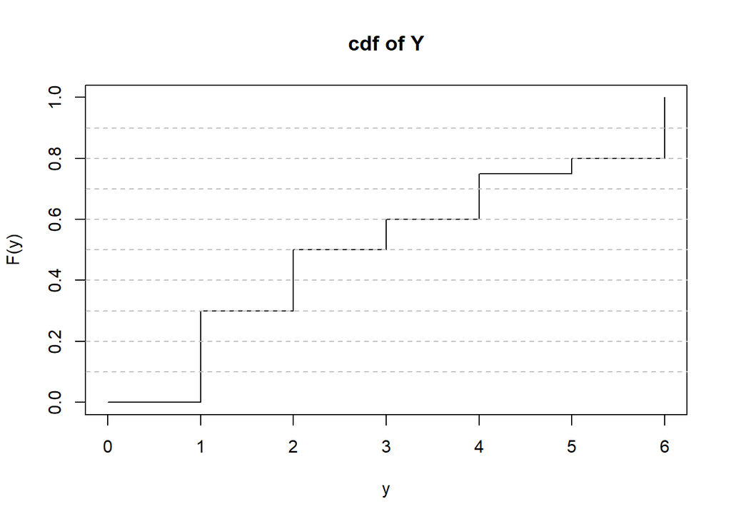

```r
plot(x=0:6, y=c(0, .3, .5, .6, .75, .8, 1), type="s", ylab="F(y)", xlab="y", main="cdf of Y")
abline(h=seq(.1,.9,.1), lty=2, col="gray")
```

Express the pmf of $Y$ in the following R code (in other words, fill in the missing probabilities)

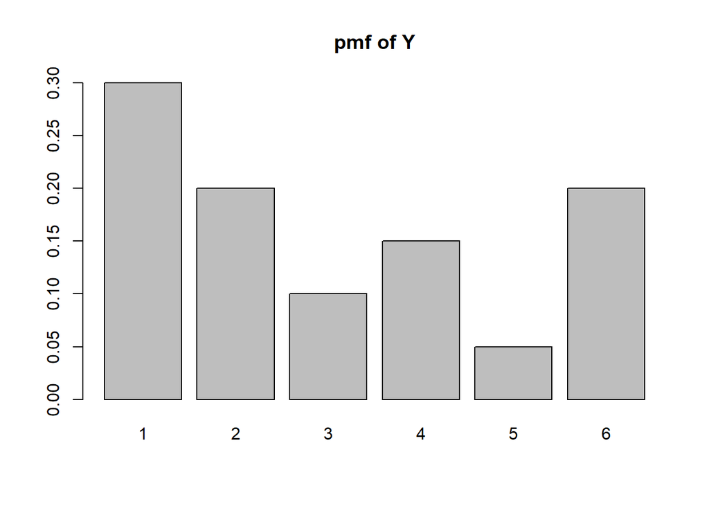

```r
y<- 1:6
py <- c(.3, .2, .1, .15, .05, .2) ## edit this line
barplot(height=py, names=y, main="pmf of Y")
```

2. Calculate $E[Y]$ for the variable $Y$ in part a.

```r
sum(y * py)
```

```
## [1] 3.05
```

## Problem 4 (2pts each, 4pts total)

Below you will find the plot of a probability density function for a random variable $X$.

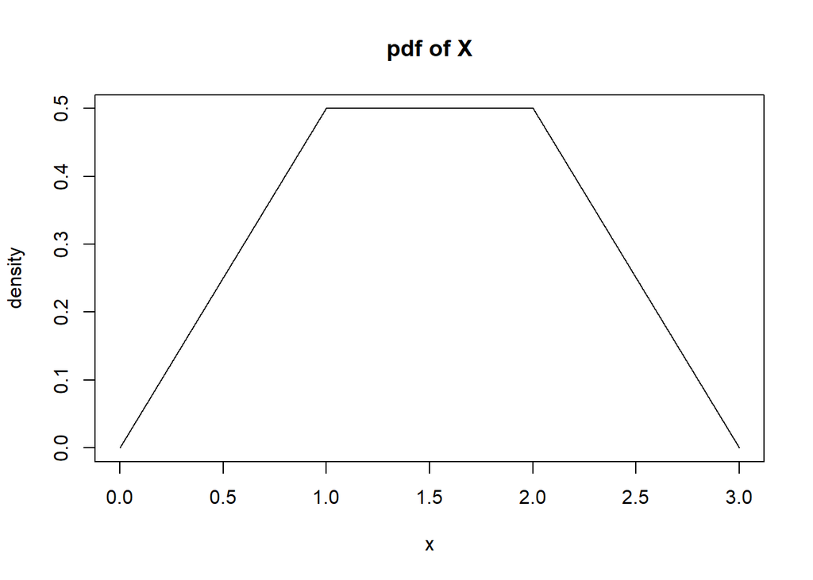

Using just geometry answer a and b:

1. What is $Pr[X < 1]$?

We see this will be the area of a triangle with $l = 1$, $h = .5$.

$$P[X < 1] = \frac{1}{2}^2$$

2. What is $Pr[1.5 < X < 2.5]$

$$Pr[1.5 < X < 2.5] = P[1.5 < X
< 2] + P[2 < X < 2.5] = P[1.5 < X < 2] + (P[2 < X <
3] - P[2.5 < X < 3])$$
$$P[1.5
< X < 2] = \frac{1}{4}, P[2 < X < 3] - P[2.5 < X < 3]
= \frac{1}{4} - \frac{1}{16}$$
$$Pr[1.5 < X < 2.5] =
\frac{7}{16}$$